# Impacto del Covid-19 en la natalidad en Chile

18/02/2022

## Tabla de Contenido

1. Objetivos
2. Datos
3. Metodología
4. Resultados
5. Discusión

## Objetivos

- Analizar la relación entre la Natalidad y el Covid-19 en Chile.
- Medir el impacto del Covid-19 en la Natalidad a nivel país.
- Medir el impacto del Covid-19 en la Natalidad a nivel de regiones.

## Datos

- **Nacimientos** : Se obtienen los datos de los nacimientos diarios por región y comuna desde el año 2010. (1)

| Region | Codigo.region | Comuna | Codigo.comuna | Nacimientos | Fecha | Ano | Mes |
| --- | --- | --- | --- | --- | --- | --- | --- |
| Tarapacá | 1 | Iquique | 1101 | 28 | 2021-01-04 | 2021 | 1 |
| Tarapacá | 1 | Iquique | 1101 | 13 | 2021-01-05 | 2021 | 1 |
| Tarapacá | 1 | Iquique | 1101 | 17 | 2021-01-06 | 2021 | 1 |

*Para el análisis se agregarán los nacimientos por mes y región*

## Datos

- **Población Estimada** : Se obtienen los datos de la población estimada y proyectada de cada año (al 30 de Junio) desde el año 2002 al 2035. Se encuentra a nivel de región, edad y sexo. (2)

| Region | Sexo | Edad | a2002 | a2003 | a2004 | a2005 | a2006 |
| --- | --- | --- | --- | --- | --- | --- | --- |
| 1 | 1 | 0 | 2345 | 2362 | 2442 | 2462 | 2457 |
| 1 | 1 | 1 | 2357 | 2344 | 2363 | 2443 | 2463 |
| 1 | 1 | 2 | 2358 | 2358 | 2346 | 2365 | 2446 |

*Para el análisis se agregarán los datos por año y región*

## Metodología

### Indicadores

El indicador principal de los análisis será la **tasa mensual de natalidad por 1000 habitantes** que se define como:

\[ \text{Tasa de Natalidad}_{ij} = \frac{\text{Nacimientos}_i}{\text{Población}_j}\cdot 1000 \cdot 12 \ \] Donde: \[ \text{i = Ene,Feb,...,Dic (mes) } \text{ y j = 2016, 2017 ,..., 2021 (año)} \]

## Metodología

### Comparación de Medias

Para analizar si existe un impacto del Covid-19 en la Natalidad se comparará la natalidad en dos periodos, antes de la pandemia y después de esta. Se utilizará un test t donde los datos proceden de poblaciones independientes.

\[ H_0 : \mu_\text{pre-pandemia} = \mu_\text{post-pandemia}\\ H_1:\mu_\text{pre-pandemia} \neq \mu_\text{post-pandemia} \]

## Metodología

### Series Temporales

Se utilizarán dos enfoques:

- Ajustar un modelo de regresión con errores ARIMA. Se aprovecha autocorrelación y se puede medir si el impacto de la pandemia es significativo.

\[y_t = \beta_0+\beta_{1}x_t+\eta_t\\\text{donde: }\eta_t\sim ARIMA(p,1,q) \] En este caso d=1 , ya que existe una tendencia (decreciente).

## Metodología

### Series Temporales

- Se ajustarán modelos ARIMA usando los datos de la serie desde el año 2016 a Noviembre del 2020. Para posteriormente predecir que hubiera sido lo más probable que ocurriera sin pandemia. Esto se visualizará gráficamente.

## Resultados

Tabla : Comparación de medias de tasa de natalidad pre y post pandemia

| \(\text{Región}\) | \(\mu_\text{pre}\) | \(\mu_\text{post}\) | \(pvalue\) | \(IC\) |
| --- | --- | --- | --- | --- |
| Tarapacá | 12.23 | 11.28 | 0.034*** | [ 0.08 , 1.83 ] |
| Antofagasta | 10.80 | 9.73 | 0*** | [ 0.54 , 1.61 ] |
| Atacama | 10.19 | 9.23 | 0.006*** | [ 0.3 , 1.6 ] |
| Coquimbo | 9.59 | 8.69 | 0*** | [ 0.46 , 1.34 ] |
| Valparaíso | 9.41 | 8.49 | 0*** | [ 0.46 , 1.37 ] |
| Libertador General Bernardo O’Higgins | 10.30 | 9.26 | 0*** | [ 0.55 , 1.53 ] |
| Maule | 9.70 | 8.56 | 0*** | [ 0.73 , 1.55 ] |
| Biobío | 10.04 | 8.97 | 0*** | [ 0.55 , 1.57 ] |
| La Araucanía | 10.18 | 9.64 | 0.076 | [ -0.06 , 1.13 ] |
| Los Lagos | 10.26 | 9.41 | 0.002*** | [ 0.36 , 1.34 ] |
| Aysén del General Carlos Ibáñez del Campo | 9.35 | 8.72 | 0.105 | [ -0.14 , 1.41 ] |
| Magallanes y de la Antártica Chilena | 9.14 | 8.13 | 0.002*** | [ 0.43 , 1.59 ] |
| Metropolitana de Santiago | 10.32 | 9.15 | 0*** | [ 0.62 , 1.72 ] |
| Los Ríos | 9.14 | 7.98 | 0*** | [ 0.69 , 1.64 ] |
| Arica y Parinacota | 11.47 | 9.99 | 0*** | [ 0.73 , 2.21 ] |
| Ñuble | 9.44 | 8.54 | 0.003*** | [ 0.34 , 1.47 ] |
| Total | 10.13 | 9.08 | 0*** | [ 0.61 , 1.48 ] |

Note:  
t-test bilateral usando un p-value de 0.05 (***).Periodo pre-pandemia ( Dic-19 a Nov-20) y periodo post-pandemia ( Dic-20 a Nov-21).

## Resultados

### Serie Temporal - Chile

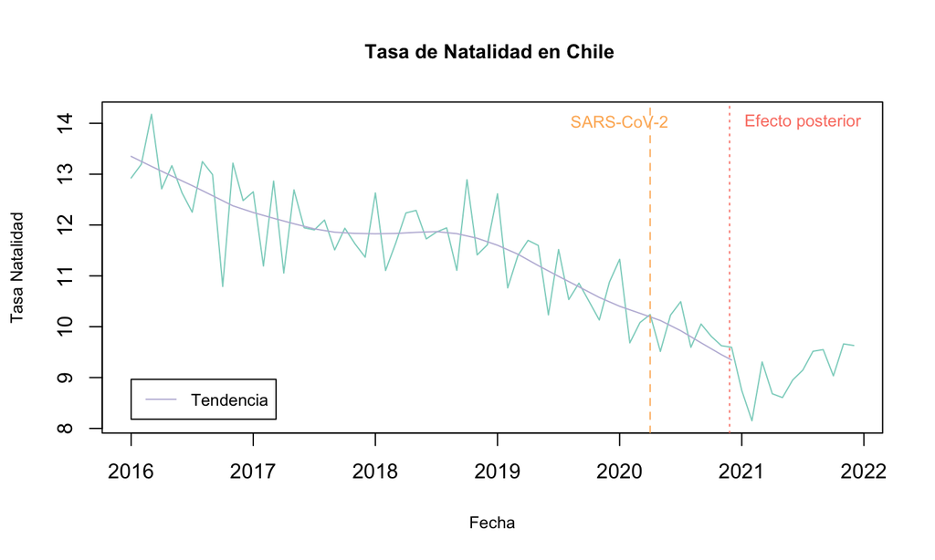

Descomposición de la serie (tendencia) se realizó con el método STL (Seasonal and Trend decomposition using Loess).

## Resultados

### Total País

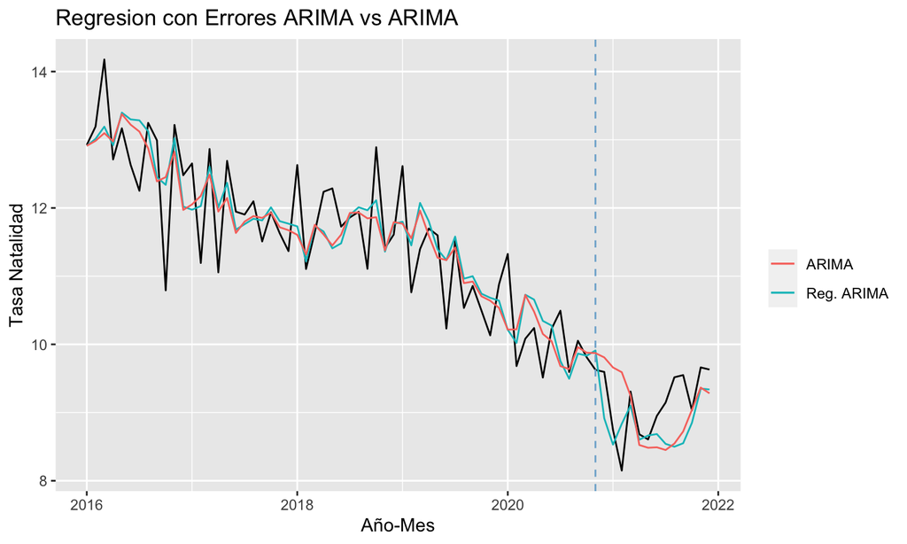

## Resultados

### Total País

Tabla: Significancia parámetros Regresión ARIMA

|  | \(\text{Estimado}\) | \(pvalue\) | \(\text{IC}\) |
| --- | --- | --- | --- |
| \(\theta_1\) | -1.262 | 0*** | [-1.47,-1.05] |
| \(\theta_2\) | 0.591 | 0*** | [0.39,0.79] |
| \(c\) | -0.040 | 0.07 | [-0.08,0] |
| \(\beta_1\) | -1.015 | 0.001*** | [-1.59,-0.44] |

Note:  
\(\beta_1\) en este caso es la variable dummy que indica el efecto de la pandemia con un retraso de 9 meses desde el comienzo de esta (0 = sin pandemia , 1 = con pandemia).Significancia de los parámetros con test de Wald usando un p-value = 0.05***.

el modelo ajustado para el total país es:

\[y_t=\ \beta_0+\beta_1X_t+\eta_t\\\\\eta_t\ =\ \eta_{t-1}+c\ +{\varepsilon\ }_t\ -\theta_1{\varepsilon\ }_{t-1}\ -\theta_2{\varepsilon\ }_{t-2}\\{\varepsilon\ }_t\sim N(0;\sigma^2) \]

## Resultados

### Por región:

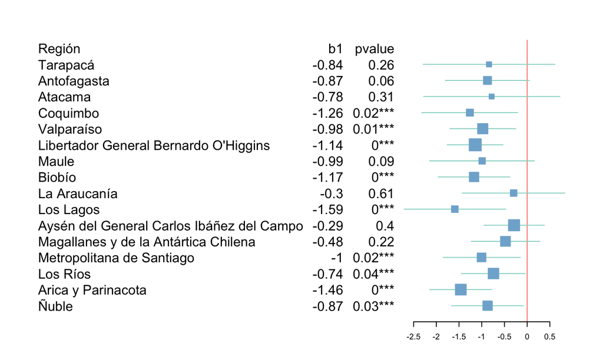

beta1 representa el coeficiente estimado de la variable dummy pandemia del modelo de regresión con errores ARIMA ajustado para cada una de las regiones .Significancia del coeficiente estimado con test de Wald usando un p-value = 0.05***. Los modelos de regresión con errores ARIMA varían para cada región dependiendo del comportamiento de la serie. Modelo ajustado con datos del año 2016 al 2021.

## Resultados

### Total País - ARIMA sin pandemia.

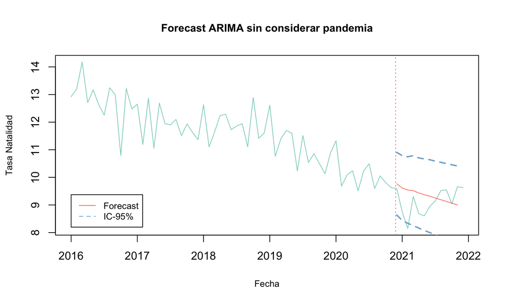

## Resultados

### Regiones - ARIMA sin pandemia.

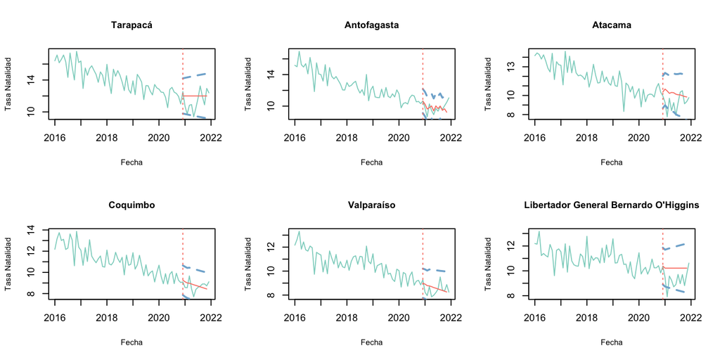

Se ajustaron los modelos ARIMA sobre la serie temporal de la tasa de natalidad de la región desde el año 2016 a Noviembre del 2020. La línea color verde representa la serie original. La roja representa la predicción media y las líneas azules discontinuas representan el intervalo de confianza al 95%.

## Resultados

### Regiones - ARIMA sin pandemia 2.

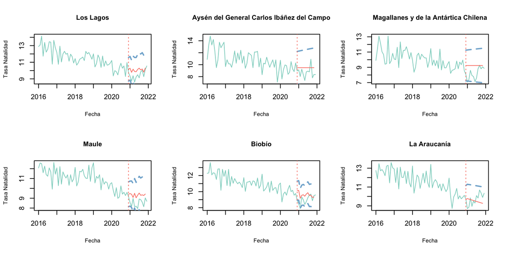

Se ajustaron los modelos ARIMA sobre la serie temporal de la tasa de natalidad de la región desde el año 2016 a Noviembre del 2020. La línea color verde representa la serie original. La roja representa la predicción media y las líneas azules discontinuas representan el intervalo de confianza al 95%.

## Resultados

### Regiones - ARIMA sin pandemia 3.

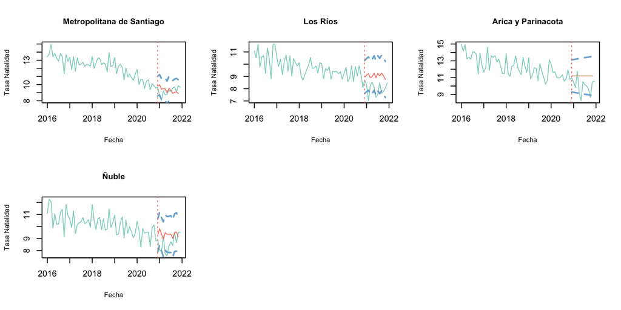

Se ajustaron los modelos ARIMA sobre la serie temporal de la tasa de natalidad de la región desde el año 2016 a Noviembre del 2020. La línea color verde representa la serie original. La roja representa la predicción media y las líneas azules discontinuas representan el intervalo de confianza al 95%.

## Discusión

- Al realizar la comparación de medias en 14 de las 16 regiones existe una diferencia significativa.
- Al aislar el efecto de la pandemia de la tendencias y estacionalidades posibles de la serie, en 9 de las 16 regiones el impacto de la pandemia es significativo.

## Discusión

- Nivel país el impacto del Covid-19 en la natalidad es de -8.77% (IC: 3.89% y 13.74%).Esto coincide con otros estudios (3)
- Comportamiento en las regiones es disímil.
  - Impacto - Recuperación.
  - Impacto - Por debajo.
  - No hubo un impacto significativo.

## Bibliografia

1. Registro Civil de Chile S de. Datos- COVID19/output/producto31 at master · MinCiencia/ Datos- COVID19 [Internet]. GitHub. [cited 2022 Feb 13]. Available from: https://github.com/MinCiencia/Datos-COVID19/blob/master/output/producto31/Nacimientos_std.csv

2. (Chile INE. Proyecciones de Población [Internet]. [cited 2022 Feb 13]. Available from: http://www.ine.cl/estadisticas/sociales/demografia-y-vitales/proyecciones-de-poblacion

3. Aassve A, Cavalli N, Mencarini L, Plach S, Sanders S. Early assessment of the relationship between the COVID-19 pandemic and births in high-income countries. Proceedings of the National Academy of Sciences [Internet]. 2021 Sep [cited 2022 Feb 18];118(36). Available from: https://www.pnas.org/content/118/36/e2105709118